# Warm-Up1

Nicholas Carey

1/27/2018

## Game of Thrones

### Samwell Tarly

[figure not shown]

> “I can’t steal her. She’s a person, not a goat.”

| Category | Description |
| --- | --- |
| Status | Alive |
| Age | 24 |
| Date of birth | 280 AC |
| Origin | Horn Hill |
| Allegiance | Nights Watch, House Tarly |
| Culture | Andal |
| Religion | Old Gods of the Forest, Faith of the Seven |
| Father | Randyll Tarly |
| Mother | Melessa Florent |

Information from http://gameofthrones.wikia.com/wiki/Samwell_Tarly

## Cooking Recipe

### Guacamole

###### Every day is Guacamole Day!!!

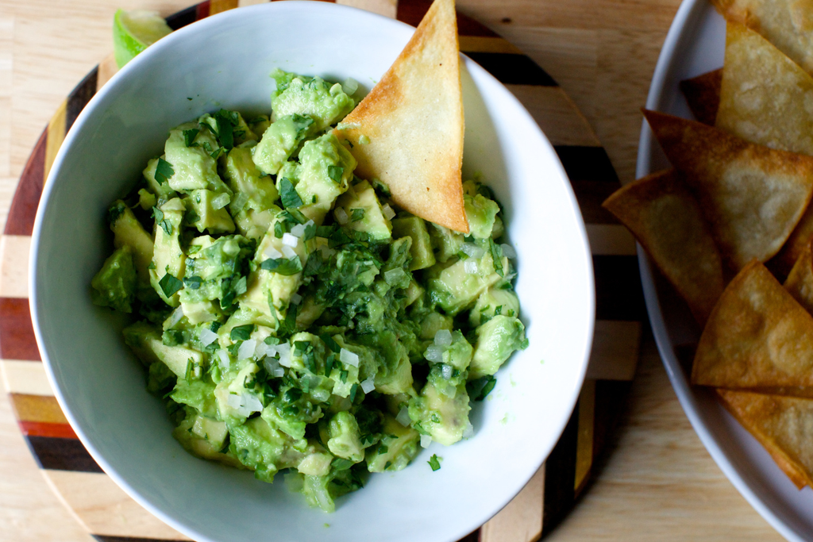

**Ingredients:**

- 2 tablespoons minced *white onion* (from about 1/8 large one)
- 1 1/2 tablespoons minced, seeded *jalapeño* (from about half a medium one)
- 2 tablespoons *cilantro* leaves, minced, plus more to taste
- 2 tablespoons diced *tomatoes*
- Juice of half a *lime*
- 1/4 teaspoon coarse or kosher *salt*, plus more to taste
- 2 medium-large ripe *avocados*

**Directions:**  
1. Mix the onion, jalapeño, tomatoes and cilantro in the bottom of a medium bowl.  
2. Add lime and salt.  
3. Cut avocado in half and remove the pit. Score the insides each half in a grid pattern.  
4. Run a spoon between the avocado and skin to scoop the chunks into the bowl. Mix it together with the other ingredients.  
5. Taste mixture, adding more of other ingredients to taste. Use a fork to mash chunks to desired consistency.  
6. Enjoy with tortilla chips! Or a spoon… I don’t judge.

*Original recipe modified from [Smitten Kitchen](https://smittenkitchen.com/2017/02/guacamole/)*

## The Quadratic Equation

$$ax^2 + bx + c = 0$$
The **Quadratic Equation** is a general representation of a second degree polynomial where a,b, and c are *coefficients* and a does not equal zero, and where x is a *variable*. When graphed versus x, a second degree polynomial forms a parabola. Using the formula below, the quadratic equation can be solved for x.
$$x = \frac{-b \pm \sqrt{b^2 - 4ac}}{2a}$$

**Derivation:**
$$ax^2 + bx + c = 0 \\
4a^2x^2 + 4abx + 4ac = 0 \\
4a^2x^2 + 4abx = -4ac \\
4a^2x^2 + 4abx + b^2 = b^2 - 4ac \\
(2ax + b)^2 = b^2 - 4ac \\
2ax + b = \pm\sqrt{b^2 - 4ac} \\
2ax = -b \pm\sqrt{b^2 - 4ac} \\
x = \frac{-b \pm\sqrt{b^2 - 4ac}}{2a}$$

## Comments and Reflection

1. What things were hard, even though you saw them in class?
   - Writing equations in LaTeX syntax was difficult because I was not familiar with it yet.
2. What was easy(-ish) even though we haven’t done it in class?
   - I found including links and images rather easy.
3. Was this the first time you were using markdown? If yes, how do you feel about it?
   - This was not my first time but I have only used it a few times before. Markdown is relatively intuitive once you get used to the perlance.
4. If you have used markdown before, was there something new you learned while doing this assignment?
   - I learned how to make a table. However the base markdown tables seem somewhat limited.
5. Did you need help to complete the assignment? If so, what kind of help? Who helped you?
   - No I did not need help completing this assignment. When I didn’t know how to do something I mostly used the Markdown Quick Reference or Google.
6. How much time did it take to complete this HW?
   - I did this assignement in multiple sittings and played around with the formatting alot. If I were to try to complete this assignment as quickly as possible, I believe I could do it in around 30 minutes.
7. What was the most time consuming part?
   - I spent a long time trying to make a table without a header and eventually discovered this was not supported.